# R Notebook

Call Libraries

```r
library(tidyverse)
library(janitor)
library(here)
library(lubridate)
```

**Labour_Productivity-OECD_Countries**

Read data

```r
gdp_phw <- read_csv(here("raw_data/OECD_GDP_per_Hour_Worked_JHios.csv")) %>%
  clean_names()
glimpse(gdp_phw)
```

```
Rows: 3,814
Columns: 8
$ location   <chr> "AUS", "AUS", "AUS", "AUS", "AUS", "AUS", "AUS", "AUS", "AUS", "AUS", "AUS", "AUS", "AUS", "AUS", "AUS", "AUS", "AUS", "AUS", "AUS"~
$ indicator  <chr> "GDPHRWKD", "GDPHRWKD", "GDPHRWKD", "GDPHRWKD", "GDPHRWKD", "GDPHRWKD", "GDPHRWKD", "GDPHRWKD", "GDPHRWKD", "GDPHRWKD", "GDPHRWKD",~
$ subject    <chr> "TOT", "TOT", "TOT", "TOT", "TOT", "TOT", "TOT", "TOT", "TOT", "TOT", "TOT", "TOT", "TOT", "TOT", "TOT", "TOT", "TOT", "TOT", "TOT"~
$ measure    <chr> "USD", "USD", "USD", "USD", "USD", "USD", "USD", "USD", "USD", "USD", "USD", "USD", "USD", "USD", "USD", "USD", "USD", "USD", "USD"~
$ frequency  <chr> "A", "A", "A", "A", "A", "A", "A", "A", "A", "A", "A", "A", "A", "A", "A", "A", "A", "A", "A", "A", "A", "A", "A", "A", "A", "A", "~
$ time       <dbl> 1970, 1971, 1972, 1973, 1974, 1975, 1976, 1977, 1978, 1979, 1980, 1981, 1982, 1983, 1984, 1985, 1986, 1987, 1988, 1989, 1990, 1991,~
$ value      <dbl> 26.84966, 27.51984, 28.12699, 28.70706, 28.24612, 29.29258, 29.78026, 29.74578, 31.00299, 31.16227, 31.51076, 32.41978, 32.80942, 3~
$ flag_codes <chr> NA, NA, NA, NA, NA, NA, NA, NA, NA, NA, NA, NA, NA, NA, NA, NA, NA, NA, NA, NA, NA, NA, NA, NA, NA, NA, NA, NA, NA, NA, NA, NA, NA,~
```

Change time in datetime format

```r
gdp_phw <- gdp_phw %>%
  mutate(time = make_datetime(time))
```

Check for NA values

```r
gdp_phw %>%
  summarise(across(.cols = everything(),
                   .fns = ~sum(is.na(.x))))
```

| location | indicator | subject | measure | frequency | time | value | flag_codes |
| --- | --- | --- | --- | --- | --- | --- | --- |
| 0 | 0 | 0 | 0 | 0 | 0 | 0 | 3760 |

View data

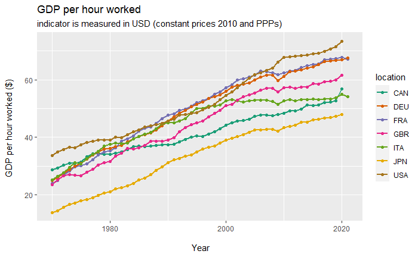

```r
gdp_phw %>%
  select(-c(indicator, subject, frequency, flag_codes)) %>%
  filter(
    location %in% c("CAN", "FRA", "DEU", "ITA", "JPN", "USA", "GBR"),
    measure == "USD") %>%
  ggplot() +
  aes(x = time, y = value, colour = location) +
  geom_line(size = 0.75) +
  geom_point(size = 1.5) +
  scale_colour_brewer(palette = "Dark2") +
  ggtitle(
    "GDP per hour worked",
    subtitle =  "indicator is measured in USD (constant prices 2010 and PPPs)"
  ) +
  labs(
    x = "\n Year",
    y = "GDP per hour worked ($) \n"
  )
```

```r
NA
```

G-7 GDP per hour worked data

```r
gdp_phw_g7 <- gdp_phw %>%
  filter(
    location %in% c("CAN", "FRA", "DEU", "ITA", "JPN", "USA", "GBR"),
    measure == "USD"
  ) %>%
  select(-c(indicator, frequency, measure, subject, flag_codes)) %>%
  rename(gdp_phw_usd = value)
```

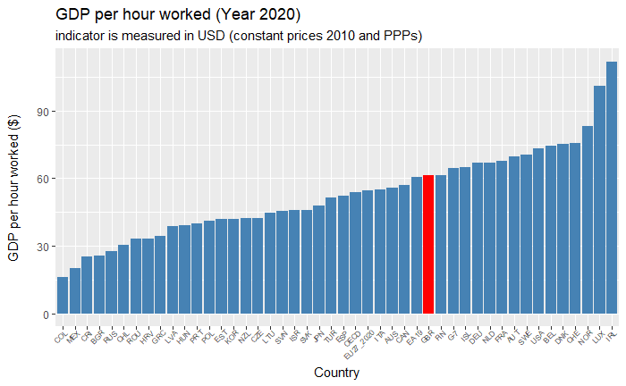

```r
gdp_phw %>%
  mutate(time = year(time)) %>%
  filter(
    # LOCATION %in% c("G-7", "EU28", "CAN", "FRA", "DEU", "ITA", "JPN", "USA", "GBR"),
    measure == "USD",
    time == 2020
    ) %>%
  select(-c(indicator, frequency, measure, subject, time, flag_codes)) %>%
  ggplot() +
  aes(
    x = reorder(location, value),
    y = value,
    fill = reorder(location, value) == "GBR"
    ) +
  geom_col() +
  scale_fill_manual(values = c('steelblue', 'red'), guide = "none") +
  theme(
    axis.text.x = element_text(size = 6, angle = 45, vjust = 1.15, hjust = 1) ) +
  ggtitle(
    "GDP per hour worked (Year 2020)",
    subtitle =  "indicator is measured in USD (constant prices 2010 and PPPs)"
  ) +
  labs(
    x = "Country",
    y = "GDP per hour worked ($)\n"
  )
```

```r
NA
```

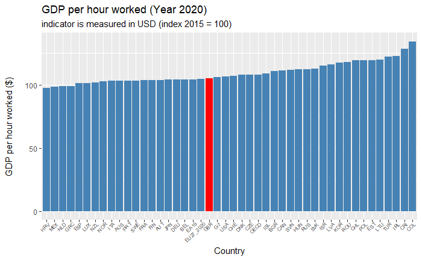

```r
gdp_phw %>%
  mutate(time = year(time)) %>%
  filter(
    # LOCATION %in% c("G-7", "EU28", "CAN", "FRA", "DEU", "ITA", "JPN", "USA", "GBR"),
    measure == "IDX2015",
    time == 2020
    ) %>%
  select(-c(indicator, frequency, measure, subject, time, flag_codes)) %>%
  ggplot() +
  aes(
    x = reorder(location, value),
    y = value,
    fill = reorder(location, value) == "GBR"
    ) +
  geom_col() +
  scale_fill_manual(values = c('steelblue', 'red'), guide = "none") +
  theme(
    axis.text.x = element_text(size = 6, angle = 45, vjust = 1.15, hjust = 1)
    ) +
  ggtitle(
    "GDP per hour worked (Year 2020)",
    subtitle =  "indicator is measured in USD (index 2015 = 100)"
  ) +
  labs(
    x = "Country",
    y = "GDP per hour worked ($)\n"
  )
```

**Cross Country Gross Domestic Spending on R&D**

Read data

```r
gdexp_rnd <- read_csv(here("raw_data/OECD_Gross_Domestic_Spending_on_R&D_JHios.csv")) %>%
  clean_names()
glimpse(gdexp_rnd)
```

```
Rows: 2,818
Columns: 8
$ location   <chr> "AUS", "AUS", "AUS", "AUS", "AUS", "AUS", "AUS", "AUS", "AUS", "AUS", "AUS", "AUS", "AUS", "AUS", "AUS", "AUS", "AUS", "~
$ indicator  <chr> "GDEXPRD", "GDEXPRD", "GDEXPRD", "GDEXPRD", "GDEXPRD", "GDEXPRD", "GDEXPRD", "GDEXPRD", "GDEXPRD", "GDEXPRD", "GDEXPRD",~
$ subject    <chr> "TOT", "TOT", "TOT", "TOT", "TOT", "TOT", "TOT", "TOT", "TOT", "TOT", "TOT", "TOT", "TOT", "TOT", "TOT", "TOT", "TOT", "~
$ measure    <chr> "MLN_USD", "MLN_USD", "MLN_USD", "MLN_USD", "MLN_USD", "MLN_USD", "MLN_USD", "MLN_USD", "MLN_USD", "MLN_USD", "MLN_USD",~
$ frequency  <chr> "A", "A", "A", "A", "A", "A", "A", "A", "A", "A", "A", "A", "A", "A", "A", "A", "A", "A", "A", "A", "A", "A", "A", "A", ~
$ time       <dbl> 1981, 1984, 1986, 1987, 1988, 1990, 1992, 1994, 1996, 1998, 2000, 2002, 2004, 2006, 2008, 2010, 2011, 2013, 2015, 2017, ~
$ value      <dbl> 3.528129e+03, 4.307797e+03, 5.292789e+03, 5.400783e+03, 5.737072e+03, 6.407597e+03, 7.767659e+03, 8.659268e+03, 9.802037~
$ flag_codes <lgl> NA, NA, NA, NA, NA, NA, NA, NA, NA, NA, NA, NA, NA, NA, NA, NA, NA, NA, NA, NA, NA, NA, NA, NA, NA, NA, NA, NA, NA, NA, ~
```

Change time in datetime format

```r
gdexp_rnd <- gdexp_rnd %>%
  mutate(time = make_datetime(time))
```

G-7 countries gross domestic expenditure on R&D (Million USD)

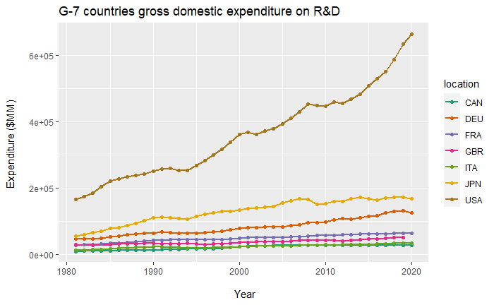

```r
gdexp_rnd %>%
  select(-c(indicator, subject, frequency, flag_codes)) %>%
  filter(location %in% c("CAN", "FRA", "DEU", "ITA", "JPN", "USA", "GBR"),
         measure == "MLN_USD") %>%
  ggplot() +
  aes(x = time, y = value, colour = location) +
  geom_line(size = 0.75) +
  geom_point(size = 1.5) +
  scale_colour_brewer(palette = "Dark2") +
  ggtitle("G-7 countries gross domestic expenditure on R&D") +
  labs(
    x = "\n Year",
    y = "Expenditure ($MM) \n"
  )
```

KEEP THIS FIGURE!!!!

G-7 countries gross domestic expenditure on R&D (% GDP)

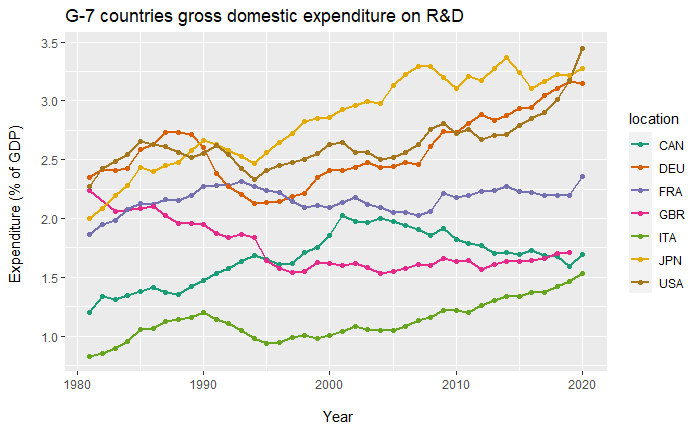

```r
gdexp_rnd %>%
  select(-c(indicator, subject, frequency, flag_codes)) %>%
  filter(
    location %in% c("CAN", "FRA", "DEU", "ITA", "JPN", "USA", "GBR"),
    measure == "PC_GDP"
    ) %>%
  ggplot() +
  aes(x = time, y = value, colour = location) +
  geom_line(size = 0.75) +
  geom_point(size = 1.5) +
  scale_colour_brewer(palette = "Dark2") +
  ggtitle("G-7 countries gross domestic expenditure on R&D") +
  labs(
    x = "\n Year",
    y = "Expenditure (% of GDP) \n"
  )
```

G-7 gross domestic expenditure on R&D (MLN USD) data

```r
gdexp_rnd_g7 <- gdexp_rnd %>%
  filter(location %in% c("CAN", "FRA", "DEU", "ITA", "JPN", "USA", "GBR"),
         measure == "MLN_USD") %>%
  select(-c(indicator, frequency, measure, subject, flag_codes)) %>%
  rename(gdexp_rnd_mil_usd = value)
```

**Compare investment between UK and other countries**

Cross country infrastructure investment

Read data

```r
infr_inv <- read_csv(here("raw_data/OECD_Infrastructure_Investment_JHios.csv")) %>%
  clean_names()
glimpse(infr_inv)
```

```
Rows: 6,279
Columns: 8
$ location   <chr> "AUS", "AUS", "AUS", "AUS", "AUS", "AUS", "AUS", "AUS", "AUS", "AUS", "AUS", "AUS", "AUS", "AUS", "AUS", "AUS", "AUS", "~
$ indicator  <chr> "INFRAINVEST", "INFRAINVEST", "INFRAINVEST", "INFRAINVEST", "INFRAINVEST", "INFRAINVEST", "INFRAINVEST", "INFRAINVEST", ~
$ subject    <chr> "RAIL", "RAIL", "RAIL", "RAIL", "RAIL", "RAIL", "RAIL", "RAIL", "RAIL", "RAIL", "RAIL", "RAIL", "RAIL", "RAIL", "RAIL", ~
$ measure    <chr> "EUR", "EUR", "EUR", "EUR", "EUR", "EUR", "EUR", "EUR", "EUR", "EUR", "EUR", "EUR", "EUR", "EUR", "EUR", "EUR", "EUR", "~
$ frequency  <chr> "A", "A", "A", "A", "A", "A", "A", "A", "A", "A", "A", "A", "A", "A", "A", "A", "A", "A", "A", "A", "A", "A", "A", "A", ~
$ time       <dbl> 1995, 1996, 1997, 1998, 1999, 2000, 2001, 2002, 2003, 2004, 2005, 2006, 2007, 2008, 2009, 2010, 2011, 2012, 2013, 2014, ~
$ value      <dbl> 571626711, 802011114, 747886519, 648492072, 564957297, 411180194, 366910464, 662954843, 748523929, 1105364376, 149628312~
$ flag_codes <chr> NA, NA, NA, NA, NA, NA, NA, NA, NA, NA, NA, NA, NA, NA, NA, NA, NA, NA, NA, NA, NA, NA, NA, NA, NA, NA, NA, NA, NA, NA, ~
```

Change time in datetime format

```r
infr_inv <- infr_inv %>%
  mutate(time = make_datetime(time))
```

Check for NA’s

```r
infr_inv %>%
  summarise(across(.cols = everything(),
                   .fns = ~sum(is.na(.x))))
```

| location | indicator | subject | measure | frequency | time | value | flag_codes |
| --- | --- | --- | --- | --- | --- | --- | --- |
| 0 | 0 | 0 | 0 | 0 | 0 | 515 | 5191 |

```r
infr_inv %>%
  distinct(subject, measure)
```

| subject | measure |
| --- | --- |
| RAIL | EUR |
| ROAD | EUR |
| INLAND | PC_GDP |
| SEA | EUR |
| AIR | EUR |
| INLANDWATER | EUR |

G-7 Cross country infrastructure investment (Euros)

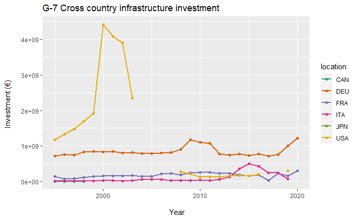

```r
infr_inv %>%
  select(-c(indicator, frequency, flag_codes)) %>%
  filter(
    location %in% c("CAN", "FRA", "DEU", "ITA", "JPN", "USA", "GBR"),
    # subject == "RAIL",
    # subject == "ROAD",
    # subject == "SEA",
    # subject == "AIR",
    subject == "INLANDWATER",
    measure == "EUR") %>%
  ggplot() +
  aes(x = time, y = value, colour = location) +
  geom_line(size = 0.75) +
  geom_point(size = 1.5) +
  scale_colour_brewer(palette = "Dark2") +
  ggtitle("G-7 Cross country infrastructure investment") +
  labs(
    x = "\n Year",
    y = "Investment (€) \n"
  )
```

G-7 Cross country infrastructure investment (% of GDP)

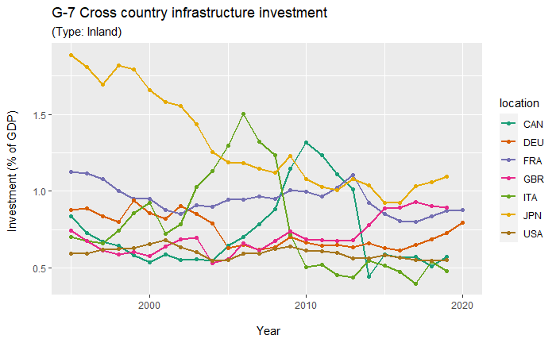

```r
infr_inv %>%
  select(-c(indicator, frequency, flag_codes)) %>%
  filter(
    location %in% c("CAN", "FRA", "DEU", "ITA", "JPN", "USA", "GBR"),
    subject == "INLAND",
    measure == "PC_GDP") %>%
  ggplot() +
  aes(x = time, y = value, colour = location) +
  geom_line(size = 0.75) +
  geom_point(size = 1.5) +
  scale_colour_brewer(palette = "Dark2") +
  ggtitle(
    "G-7 Cross country infrastructure investment",
    subtitle = "(Type: Inland)"
  ) +
  labs(
    x = "\n Year",
    y = "Investment (% of GDP) \n"
  )
```

OECD_Gross_Domestic_Product_GDP

Read data

```r
gdp <- read_csv(here("raw_data/OECD_Gross_Domestic_Product_GDP_JHios.csv")) %>%
  clean_names()
glimpse(gdp)
```

```
Rows: 5,137
Columns: 8
$ location   <chr> "AUS", "AUS", "AUS", "AUS", "AUS", "AUS", "AUS", "AUS", "AUS", "AUS", "AUS", "AUS", "AUS", "AUS", "AUS", "AUS", "AUS", "~
$ indicator  <chr> "GDP", "GDP", "GDP", "GDP", "GDP", "GDP", "GDP", "GDP", "GDP", "GDP", "GDP", "GDP", "GDP", "GDP", "GDP", "GDP", "GDP", "~
$ subject    <chr> "TOT", "TOT", "TOT", "TOT", "TOT", "TOT", "TOT", "TOT", "TOT", "TOT", "TOT", "TOT", "TOT", "TOT", "TOT", "TOT", "TOT", "~
$ measure    <chr> "MLN_USD", "MLN_USD", "MLN_USD", "MLN_USD", "MLN_USD", "MLN_USD", "MLN_USD", "MLN_USD", "MLN_USD", "MLN_USD", "MLN_USD",~
$ frequency  <chr> "A", "A", "A", "A", "A", "A", "A", "A", "A", "A", "A", "A", "A", "A", "A", "A", "A", "A", "A", "A", "A", "A", "A", "A", ~
$ time       <dbl> 1960, 1961, 1962, 1963, 1964, 1965, 1966, 1967, 1968, 1969, 1970, 1971, 1972, 1973, 1974, 1975, 1976, 1977, 1978, 1979, ~
$ value      <dbl> 25073.26, 25364.88, 27955.36, 30432.98, 32745.29, 34542.34, 38344.55, 41068.68, 46560.93, 52215.40, 58858.35, 64135.62, ~
$ flag_codes <chr> NA, NA, NA, NA, NA, NA, NA, NA, NA, NA, NA, NA, NA, NA, NA, NA, NA, NA, NA, NA, NA, NA, NA, NA, NA, NA, NA, NA, NA, NA, ~
```

Change time in datetime format

```r
gdp <- gdp %>%
  mutate(time = make_datetime(time))
```

Check for NA’s

```r
gdp %>%
  summarise(across(.cols = everything(),
                   .fns = ~sum(is.na(.x))))
```

| location | indicator | subject | measure | frequency | time | value | flag_codes |
| --- | --- | --- | --- | --- | --- | --- | --- |
| 0 | 0 | 0 | 0 | 0 | 0 | 0 | 3824 |

```r
gdp %>%
  # distinct(LOCATION)
  distinct(indicator) # GDP
```

| indicator |
| --- |
| GDP |

```r
  # distinct(SUBJECT) # TOT
  # distinct(MEASURE) # MLN_USD, USD_CAP
  # distinct(FREQUENCY) #A
  # distinct(`Flag Codes`) # NA, E, P, B, D
```

View data

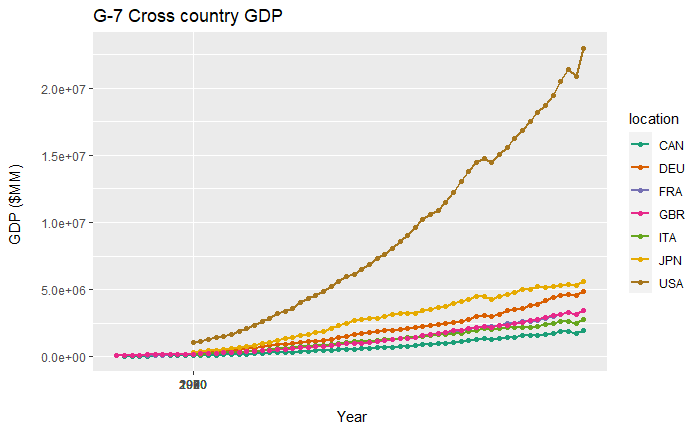

```r
gdp %>%
  select(-c(indicator, frequency, subject, flag_codes)) %>%
  filter(
    location %in% c("CAN", "FRA", "DEU", "ITA", "JPN", "USA", "GBR"),
    measure == "MLN_USD"
    ) %>%
  ggplot() +
  aes(x = time, y = value, group = location, color = location) +
  geom_line(size = 0.75) +
  geom_point(size = 1.5) +
  scale_colour_brewer(palette = "Dark2") +
  ggtitle("G-7 Cross country GDP") +
  labs(
    x = "\n Year",
    y = "GDP ($MM) \n"
  ) +
  scale_x_continuous(breaks = seq(from = 1960, to = 2020, by = 10))
```

```r
gdp_light <- gdp %>%
  filter(measure == "MLN_USD") %>%
  select(location, time, value) %>%
  rename(gdp = value)
```

```r
inv_inland_usd <- infr_inv %>%
  select(-c(indicator, frequency, flag_codes)) %>%
  filter(
    location %in% c("CAN", "FRA", "DEU", "ITA", "JPN", "USA", "GBR"),
    subject == "INLAND",
    measure == "PC_GDP"
  ) %>%
  left_join(gdp_light, by = c("location", "time")) %>%
  mutate(
    value_mil_usd = value * gdp / 100
  )

inv_inland_usd
```

| location | subject | measure | time | value | gdp | value_mil_usd |
| --- | --- | --- | --- | --- | --- | --- |
| CAN | INLAND | PC_GDP | 1995-01-01 | 0.8383868 | 688183.6 | 5769.641 |
| CAN | INLAND | PC_GDP | 1996-01-01 | 0.7305522 | 712131.0 | 5202.488 |
| CAN | INLAND | PC_GDP | 1997-01-01 | 0.6740582 | 755416.0 | 5091.944 |
| CAN | INLAND | PC_GDP | 1998-01-01 | 0.6445240 | 793682.1 | 5115.472 |
| CAN | INLAND | PC_GDP | 1999-01-01 | 0.5847704 | 846421.3 | 4949.621 |
| CAN | INLAND | PC_GDP | 2000-01-01 | 0.5373112 | 901003.3 | 4841.191 |
| CAN | INLAND | PC_GDP | 2001-01-01 | 0.5898465 | 937793.0 | 5531.540 |
| CAN | INLAND | PC_GDP | 2002-01-01 | 0.5510657 | 971009.1 | 5350.898 |
| CAN | INLAND | PC_GDP | 2003-01-01 | 0.5581227 | 1023686.5 | 5713.427 |
| CAN | INLAND | PC_GDP | 2004-01-01 | 0.5483169 | 1083615.2 | 5941.645 |

[output cut: 167 more lines]

G-7 Cross country INLAND infrastructure investment ($MM)

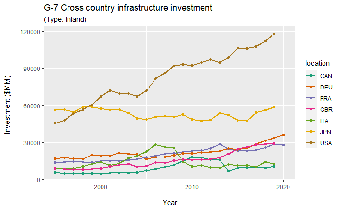

```r
inv_inland_usd %>%
  select(-c(subject, measure, value, gdp)) %>%
  filter(
    location %in% c("CAN", "FRA", "DEU", "ITA", "JPN", "USA", "GBR")) %>%
  ggplot() +
  aes(x = time, y = value_mil_usd, colour = location) +
  geom_line(size = 0.75) +
  geom_point(size = 1.5) +
  scale_colour_brewer(palette = "Dark2") +
  ggtitle(
    "G-7 Cross country infrastructure investment",
    subtitle = "(Type: Inland)"
  ) +
  labs(
    x = "\n Year",
    y = "Investment ($MM) \n"
  )
```

G-7 infrastructure investment data

```r
infr_inv_g7 <- infr_inv %>%
  filter(
    location %in% c("CAN", "FRA", "DEU", "ITA", "JPN", "USA", "GBR")
  ) %>%
  select(-c(indicator, frequency, measure, flag_codes)) %>%
  pivot_wider(names_from = subject, values_from = value) %>%
  mutate(
    RAIL = RAIL/1e6,
    ROAD = ROAD/1e6,
    INLAND = INLAND,
    AIR = AIR/1e6,
    SEA = SEA/1e6,
    INLANDWATER = INLANDWATER/1e6
  ) %>%
  rename(
    rail_mil_eur = RAIL,
    road_mil_eur = ROAD,
    inland_pc_gdp = INLAND,
    air_mil_eur = AIR,
    sea_mil_eur = SEA,
    inlandwater_mil_eur = INLANDWATER
  ) %>%
  left_join(gdp_light, by = c("location", "time")) %>%
  mutate(
    inland_mil_usd = inland_pc_gdp * gdp / 100
  ) %>%
  select(-inland_pc_gdp, -gdp)
```

```r
infr_inv %>%
  filter(
    location %in% c("GBR"),
    subject == "INLANDWATER"
  )
```

| location | indicator | subject | measure | frequency | time | value | flag_codes |
| --- | --- | --- | --- | --- | --- | --- | --- |

OECD Education Spending Expenditure

Read data

```r
edu_exp <- read_csv(here("raw_data/OECD_Public_Spending_on_Education_JHios.csv")) %>%
  clean_names()
glimpse(edu_exp)
```

```
Rows: 1,620
Columns: 8
$ location   <chr> "AUS", "AUS", "AUS", "AUS", "AUS", "AUS", "AUS", "AUS", "AUS", "AUS", "AUS", "AUS", "AUS", "AUT", "AUT", "AUT", "AUT", "~
$ indicator  <chr> "EDUPUBEXP", "EDUPUBEXP", "EDUPUBEXP", "EDUPUBEXP", "EDUPUBEXP", "EDUPUBEXP", "EDUPUBEXP", "EDUPUBEXP", "EDUPUBEXP", "ED~
$ subject    <chr> "TRY", "TRY", "TRY", "TRY", "TRY", "TRY", "TRY", "TRY", "TRY", "TRY", "TRY", "TRY", "TRY", "TRY", "TRY", "TRY", "TRY", "~
$ measure    <chr> "PC_GDP", "PC_GDP", "PC_GDP", "PC_GDP", "PC_GDP", "PC_GDP", "PC_GDP", "PC_GDP", "PC_GDP", "PC_GDP", "PC_GDP", "PC_GDP", ~
$ frequency  <chr> "A", "A", "A", "A", "A", "A", "A", "A", "A", "A", "A", "A", "A", "A", "A", "A", "A", "A", "A", "A", "A", "A", "A", "A", ~
$ time       <dbl> 2000, 2005, 2008, 2009, 2010, 2011, 2012, 2013, 2014, 2015, 2016, 2017, 2018, 2012, 2013, 2014, 2015, 2016, 2017, 2018, ~
$ value      <dbl> 0.7460824, 0.6911921, 0.6902357, 0.7358844, 0.7797844, 0.7440488, 0.7194145, 0.7188712, 0.7170264, 0.7682429, 0.7551060,~
$ flag_codes <lgl> NA, NA, NA, NA, NA, NA, NA, NA, NA, NA, NA, NA, NA, NA, NA, NA, NA, NA, NA, NA, NA, NA, NA, NA, NA, NA, NA, NA, NA, NA, ~
```

Change time in datetime format

```r
edu_exp <- edu_exp %>%
  mutate(time = make_datetime(time))
```

Check for NA’s

```r
edu_exp %>%
  summarise(across(.cols = everything(),
                   .fns = ~sum(is.na(.x))))
```

| location | indicator | subject | measure | frequency | time | value | flag_codes |
| --- | --- | --- | --- | --- | --- | --- | --- |
| 0 | 0 | 0 | 0 | 0 | 0 | 0 | 1620 |

G-7 countries education expenditure (GDP percentage) TRY : TeRtiarY PRY_NTRY: PRimarY to post-secondary Non-TeRtiarY PRY_TRY: PRimarY to TeRtiarY

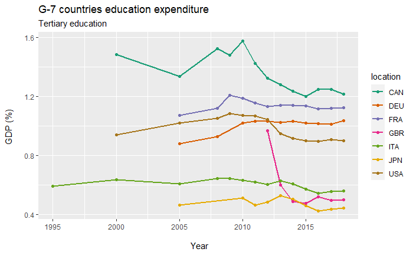

```r
edu_exp %>%
  select(-c(indicator, frequency, measure, flag_codes)) %>%
  filter(
    location %in% c("CAN", "FRA", "DEU", "ITA", "JPN", "USA", "GBR"),
    subject == "TRY"
    ) %>%
  ggplot() +
  aes(x = time, y = value, colour = location) +
  geom_line(size = 0.75) +
  geom_point(size = 1.5) +
  scale_colour_brewer(palette = "Dark2") +
  # scale_colour_manual(values = cbb_palette) +
  ggtitle(
    "G-7 countries education expenditure",
    subtitle = "Tertiary education"
  ) +
  labs(
    x = "\n Year",
    y = "GDP (%) \n"
  )
```

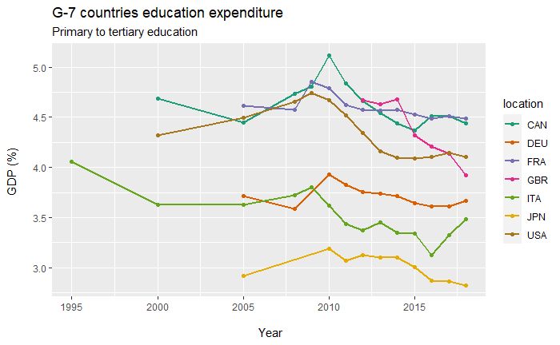

```r
edu_exp %>%
  select(-c(indicator, frequency, measure, flag_codes)) %>%
  filter(
    location %in% c("CAN", "FRA", "DEU", "ITA", "JPN", "USA", "GBR"),
    subject == "PRY_TRY"
    ) %>%
  ggplot() +
  aes(x = time, y = value, colour = location) +
  geom_line(size = 0.75) +
  geom_point(size = 1.5) +
  scale_colour_brewer(palette = "Dark2") +
  # scale_colour_manual(values = cbb_palette) +
  ggtitle(
    "G-7 countries education expenditure",
    subtitle = "Primary to tertiary education"
  ) +
  labs(
    x = "\n Year",
    y = "GDP (%) \n"
  )
```

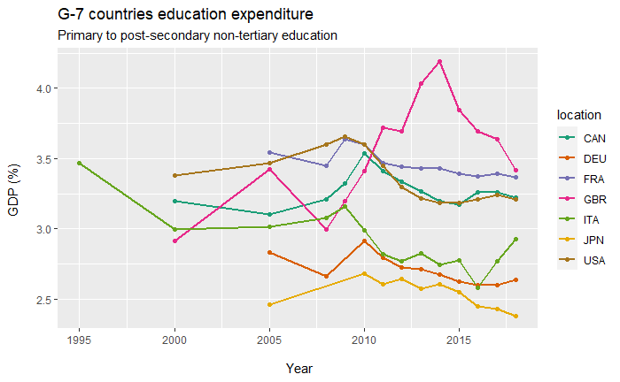

```r
edu_exp %>%
  select(-c(indicator, frequency, measure, flag_codes)) %>%
  filter(
    location %in% c("CAN", "FRA", "DEU", "ITA", "JPN", "USA", "GBR"),
    subject == "PRY_NTRY"
    ) %>%
  ggplot() +
  aes(x = time, y = value, colour = location) +
  geom_line(size = 0.75) +
  geom_point(size = 1.5) +
  scale_colour_brewer(palette = "Dark2") +
  # scale_colour_manual(values = cbb_palette) +
  ggtitle(
    "G-7 countries education expenditure",
    subtitle = "Primary to post-secondary non-tertiary education"
  ) +
  labs(
    x = "\n Year",
    y = "GDP (%) \n"
  )
```

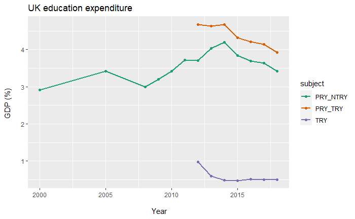

```r
edu_exp %>%
  select(-c(indicator, frequency, measure, flag_codes)) %>%
  filter(location %in% c("GBR")) %>%
  ggplot() +
  aes(x = time, y = value, colour = subject) +
  geom_line(size = 0.75) +
  geom_point(size = 1.5) +
  scale_colour_brewer(palette = "Dark2") +
  # scale_colour_manual(values = cbb_palette) +
  ggtitle("UK education expenditure") +
  labs(
    x = "\n Year",
    y = "GDP (%) \n"
  )
```

```r
edu_exp_usd <- edu_exp %>%
  left_join(gdp_light, by = c("location", "time")) %>%
  mutate(
    value_mil_usd = value * gdp / 100
  )
```

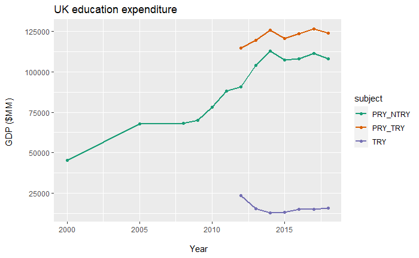

```r
edu_exp_usd %>%
  select(-c(indicator, frequency, measure, flag_codes)) %>%
  filter(location %in% c("GBR")) %>%
  ggplot() +
  aes(x = time, y = value_mil_usd, colour = subject) +
  geom_line(size = 0.75) +
  geom_point(size = 1.5) +
  scale_colour_brewer(palette = "Dark2") +
  # scale_colour_manual(values = cbb_palette) +
  ggtitle("UK education expenditure") +
  labs(
    x = "\n Year",
    y = "GDP ($MM) \n"
  )
```

G-7 expenditure on education data

```r
edu_exp_g7 <- edu_exp %>%
  filter(
    location %in% c("CAN", "FRA", "DEU", "ITA", "JPN", "USA", "GBR")
    ) %>%
  select(-c(indicator, frequency, measure, flag_codes)) %>%
  pivot_wider(names_from = subject, values_from = value) %>%
  rename(
    try_pc_gdp = TRY,
    pry_ntry_pc_gdp = PRY_NTRY,
    pry_try_pc_gdp = PRY_TRY
  ) %>%
  left_join(gdp_light, by = c("location", "time"))%>%
  mutate(
    try_mil_usd = try_pc_gdp * gdp / 100,
    pry_ntry_mil_usd = pry_ntry_pc_gdp * gdp / 100,
    pry_try_mil_usd = pry_try_pc_gdp * gdp / 100
  ) %>%
  select(-try_pc_gdp, -pry_ntry_pc_gdp, -pry_try_pc_gdp, -gdp)
```

**Data for modelling**

```r
productivity <- gdp_phw_g7 %>%
  left_join(edu_exp_g7, by = c("location", "time")) %>%
  left_join(gdexp_rnd_g7, by = c("location", "time")) %>%
  left_join(infr_inv_g7, by = c("location", "time"))

glimpse(productivity)
```

```
Rows: 360
Columns: 13
$ location            <chr> "CAN", "CAN", "CAN", "CAN", "CAN", "CAN", "CAN", "CAN", "CAN", "CAN", "CAN", "CAN", "CAN", "CAN", "CAN", "CAN",~
$ time                <dttm> 1970-01-01, 1971-01-01, 1972-01-01, 1973-01-01, 1974-01-01, 1975-01-01, 1976-01-01, 1977-01-01, 1978-01-01, 19~
$ gdp_phw_usd         <dbl> 28.62992, 29.33436, 30.35025, 31.07351, 31.07195, 31.42778, 33.28053, 34.20403, 34.45608, 34.11693, 34.01649, 3~
$ try_mil_usd         <dbl> NA, NA, NA, NA, NA, NA, NA, NA, NA, NA, NA, NA, NA, NA, NA, NA, NA, NA, NA, NA, NA, NA, NA, NA, NA, NA, NA, NA,~
$ pry_ntry_mil_usd    <dbl> NA, NA, NA, NA, NA, NA, NA, NA, NA, NA, NA, NA, NA, NA, NA, NA, NA, NA, NA, NA, NA, NA, NA, NA, NA, NA, NA, NA,~
$ pry_try_mil_usd     <dbl> NA, NA, NA, NA, NA, NA, NA, NA, NA, NA, NA, NA, NA, NA, NA, NA, NA, NA, NA, NA, NA, NA, NA, NA, NA, NA, NA, NA,~
$ gdexp_rnd_mil_usd   <dbl> NA, NA, NA, NA, NA, NA, NA, NA, NA, NA, NA, 8603.080, 9305.246, 9332.896, 10140.339, 10915.154, 11443.570, 1151~
$ rail_mil_eur        <dbl> NA, NA, NA, NA, NA, NA, NA, NA, NA, NA, NA, NA, NA, NA, NA, NA, NA, NA, NA, NA, NA, NA, NA, NA, NA, 290.7754, 2~
$ road_mil_eur        <dbl> NA, NA, NA, NA, NA, NA, NA, NA, NA, NA, NA, NA, NA, NA, NA, NA, NA, NA, NA, NA, NA, NA, NA, NA, NA, 3575.646, 3~
$ air_mil_eur         <dbl> NA, NA, NA, NA, NA, NA, NA, NA, NA, NA, NA, NA, NA, NA, NA, NA, NA, NA, NA, NA, NA, NA, NA, NA, NA, NA, NA, NA,~
$ sea_mil_eur         <dbl> NA, NA, NA, NA, NA, NA, NA, NA, NA, NA, NA, NA, NA, NA, NA, NA, NA, NA, NA, NA, NA, NA, NA, NA, NA, 61.83155, 1~
$ inlandwater_mil_eur <dbl> NA, NA, NA, NA, NA, NA, NA, NA, NA, NA, NA, NA, NA, NA, NA, NA, NA, NA, NA, NA, NA, NA, NA, NA, NA, 5.013369, 4~
$ inland_mil_usd      <dbl> NA, NA, NA, NA, NA, NA, NA, NA, NA, NA, NA, NA, NA, NA, NA, NA, NA, NA, NA, NA, NA, NA, NA, NA, NA, 5769.641, 5~
```

Trim data

```r
prod_uk_trim <- productivity %>%
  mutate(time = year(time)) %>%
  filter(
    location == "GBR",
    time >= 1995 & time <=2019
  ) %>%
  select(
    gdp_phw_usd,
    gdexp_rnd_mil_usd,
    rail_mil_eur,
    road_mil_eur,
    inland_mil_usd
  ) %>%
  mutate(
    gdexp_rnd_bil_usd = gdexp_rnd_mil_usd / 1000,
    rail_bil_eur = rail_mil_eur / 1000,
    road_bil_eur = road_mil_eur / 1000,
    inland_bil_usd = inland_mil_usd / 1000
  ) %>%
  select(
    -gdexp_rnd_mil_usd,
    -rail_mil_eur,
    -road_mil_eur,
    -inland_mil_usd
  )
```

Check for aliases

```r
alias(lm(gdp_phw_usd ~ ., data = prod_uk_trim))
```

```
Model :
gdp_phw_usd ~ gdexp_rnd_bil_usd + rail_bil_eur + road_bil_eur +
    inland_bil_usd
```

Call libraries for linear regression modelling

```r
library(GGally)
library(ggfortify)
library(modelr)
```

Check for correlations in data

[output not shown]

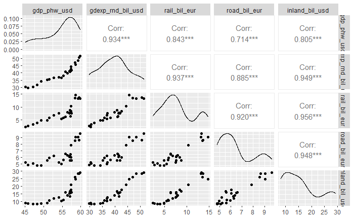

```r
ggpairs(prod_uk_trim)
```

Simple linear regression

Response: gdp_phw_usd

Predictor: gdexp_rnd_bil_usd

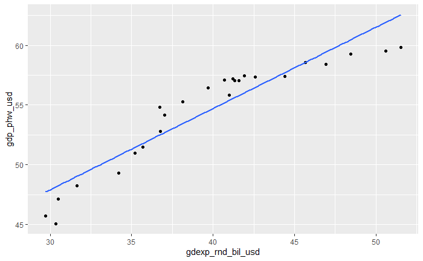

```r
prod_uk_trim %>%
  ggplot(aes(x = gdexp_rnd_bil_usd, y = gdp_phw_usd)) +
  geom_point() +
  geom_smooth(method = "lm", se = FALSE)
```

Goodness-of-fit diagnostics

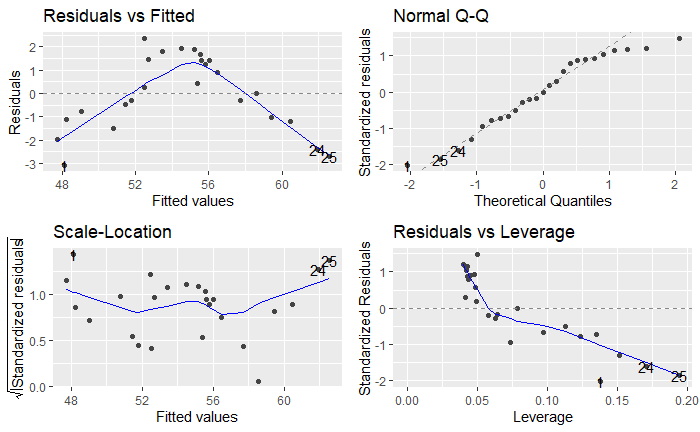

```r
model_1 <- lm(gdp_phw_usd ~ gdexp_rnd_bil_usd, data = prod_uk_trim)

autoplot(model_1) #diagnostics
```

```r
summary(model_1)
```

```
Call:
lm(formula = gdp_phw_usd ~ gdexp_rnd_bil_usd, data = prod_uk_trim)

Residuals:
     Min       1Q   Median       3Q      Max
-3.07203 -1.11322 -0.00595  1.42747  2.34488

Coefficients:
                  Estimate Std. Error t value Pr(>|t|)
(Intercept)       27.45638    2.18984   12.54 9.16e-12 ***
gdexp_rnd_bil_usd  0.68145    0.05448   12.51 9.61e-12 ***
---
Signif. codes:  0 ‘***’ 0.001 ‘**’ 0.01 ‘*’ 0.05 ‘.’ 0.1 ‘ ’ 1

Residual standard error: 1.633 on 23 degrees of freedom
Multiple R-squared:  0.8718,    Adjusted R-squared:  0.8663
F-statistic: 156.5 on 1 and 23 DF,  p-value: 9.611e-12
```

- Adding a second predictor to the model

Calculate residuals

[output not shown]

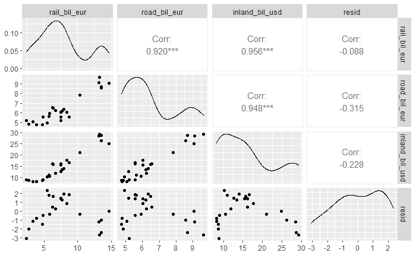

```r
prod_uk_remaining_resid <- prod_uk_trim %>%
  add_residuals(model_1) %>%
  select(-c("gdp_phw_usd", "gdexp_rnd_bil_usd"))

prod_uk_remaining_resid %>%
  ggpairs()
```

It seems that road_bil_eur is a good candidate for a second predictor followed by inland_bil_usd

Model with road_bil_eur (model_2a)

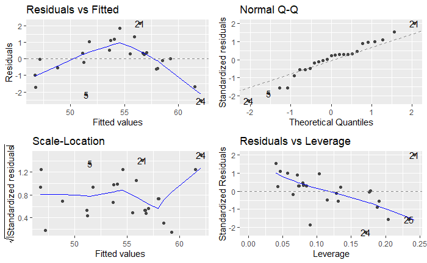

```r
model_2a <- lm(gdp_phw_usd ~ gdexp_rnd_bil_usd + road_bil_eur, data = prod_uk_trim)

autoplot(model_2a) #diagnostics
```

```r
summary(model_2a)
```

```
Call:
lm(formula = gdp_phw_usd ~ gdexp_rnd_bil_usd + road_bil_eur,
    data = prod_uk_trim)

Residuals:
    Min      1Q  Median      3Q     Max
-2.5173 -0.5917  0.2612  0.5330  2.1306

Coefficients:
                  Estimate Std. Error t value Pr(>|t|)
(Intercept)       23.95942    1.83812  13.035 7.99e-12 ***
gdexp_rnd_bil_usd  1.01792    0.08823  11.537 8.43e-11 ***
road_bil_eur      -1.54447    0.35855  -4.308 0.000285 ***
---
Signif. codes:  0 ‘***’ 0.001 ‘**’ 0.01 ‘*’ 0.05 ‘.’ 0.1 ‘ ’ 1

Residual standard error: 1.23 on 22 degrees of freedom
Multiple R-squared:  0.9305,    Adjusted R-squared:  0.9242
F-statistic: 147.2 on 2 and 22 DF,  p-value: 1.834e-13
```

Model with inland_bil_usd (model_2b)

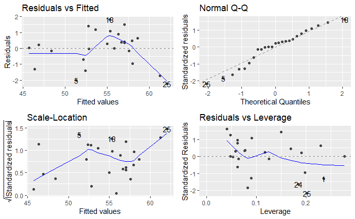

```r
model_2b <- lm(gdp_phw_usd ~ gdexp_rnd_bil_usd + inland_bil_usd, data = prod_uk_trim)

autoplot(model_2b) #diagnostics
```

```r
summary(model_2b)
```

```
Call:
lm(formula = gdp_phw_usd ~ gdexp_rnd_bil_usd + inland_bil_usd,
    data = prod_uk_trim)

Residuals:
    Min      1Q  Median      3Q     Max
-2.2256 -0.7001  0.2293  0.6348  1.8082

Coefficients:
                  Estimate Std. Error t value Pr(>|t|)
(Intercept)        13.1014     3.3041   3.965 0.000656 ***
gdexp_rnd_bil_usd   1.2514     0.1222  10.244 7.77e-10 ***
inland_bil_usd     -0.5300     0.1078  -4.916 6.46e-05 ***
---
Signif. codes:  0 ‘***’ 0.001 ‘**’ 0.01 ‘*’ 0.05 ‘.’ 0.1 ‘ ’ 1

Residual standard error: 1.153 on 22 degrees of freedom
Multiple R-squared:  0.9389,    Adjusted R-squared:  0.9334
F-statistic: 169.1 on 2 and 22 DF,  p-value: 4.412e-14
```

Results indicate that model_2b performs slightly better than model_2a. We keep model_2b for further modelling.

- Adding a third predictor to the model

Calculate residuals

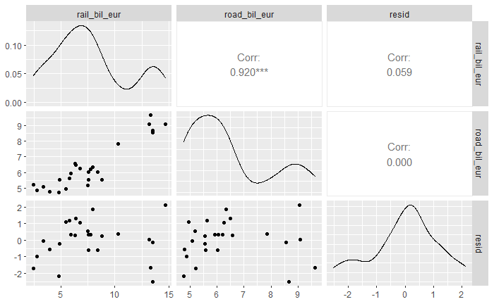

```r
prod_uk_remaining_resid <- prod_uk_trim %>%
  add_residuals(model_2a) %>%
  select(-c("gdp_phw_usd", "gdexp_rnd_bil_usd", "inland_bil_usd"))

prod_uk_remaining_resid %>%
  ggpairs()
```

Model with added road_bil_eur (model_3a)

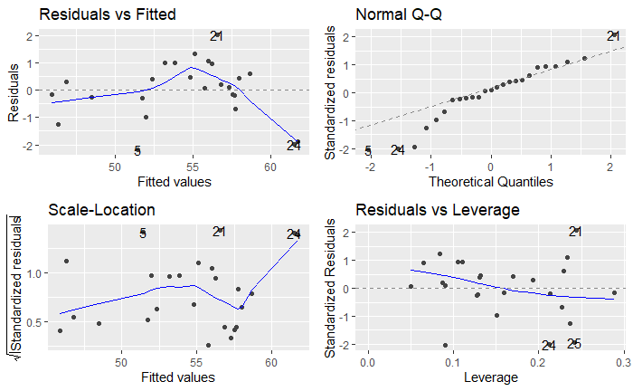

```r
model_3a <- lm(gdp_phw_usd ~ gdexp_rnd_bil_usd + inland_bil_usd + road_bil_eur, data = prod_uk_trim)

autoplot(model_3a) #diagnostics
```

```r
summary(model_3a)
```

```
Call:
lm(formula = gdp_phw_usd ~ gdexp_rnd_bil_usd + inland_bil_usd +
    road_bil_eur, data = prod_uk_trim)

Residuals:
    Min      1Q  Median      3Q     Max
-2.1685 -0.2776  0.1164  0.6168  2.0156

Coefficients:
                  Estimate Std. Error t value Pr(>|t|)
(Intercept)        16.0645     3.7926   4.236  0.00037 ***
gdexp_rnd_bil_usd   1.2253     0.1203  10.185  1.4e-09 ***
inland_bil_usd     -0.3608     0.1554  -2.321  0.03041 *
road_bil_eur       -0.7156     0.4844  -1.477  0.15447
---
Signif. codes:  0 ‘***’ 0.001 ‘**’ 0.01 ‘*’ 0.05 ‘.’ 0.1 ‘ ’ 1

Residual standard error: 1.123 on 21 degrees of freedom
Multiple R-squared:  0.9447,    Adjusted R-squared:  0.9368
F-statistic: 119.5 on 3 and 21 DF,  p-value: 2.332e-13
```

It doesn’t seem that road_bil_eur adds too much value in explaining the variability of the response.

Let’s see if adding an interaction makes any improvement in our model.

Check for including in the model potential interactions between predictors

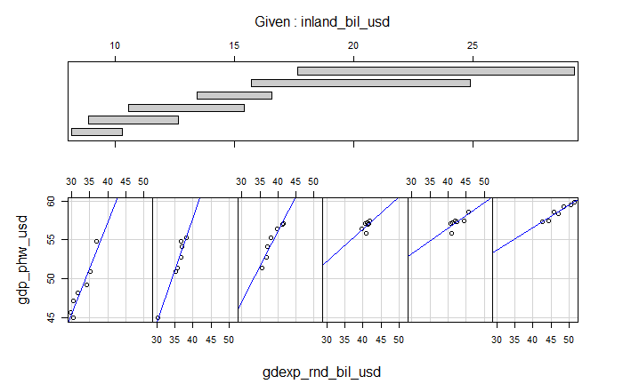

```r
coplot(gdp_phw_usd ~ gdexp_rnd_bil_usd | inland_bil_usd,
       rows = 1,
       panel = function(x, y, ...){
         points(x, y)
         abline(lm(y ~ x), col = "blue")
       },
       data = prod_uk_trim)
```

Model with added gdexp_rnd_bil_usd:inland_bil_usd (model_3b)

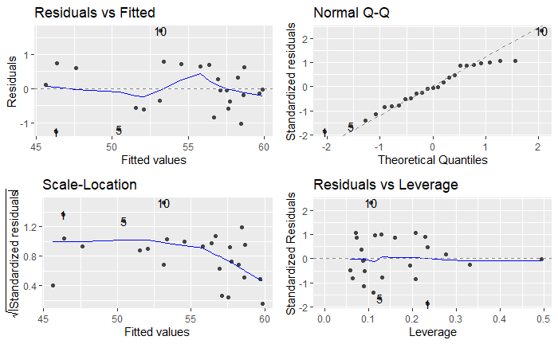

```r
model_3b <- lm(gdp_phw_usd ~ gdexp_rnd_bil_usd + inland_bil_usd + gdexp_rnd_bil_usd:inland_bil_usd, data = prod_uk_trim)

autoplot(model_3b) #diagnostics
```

```r
summary(model_3b)
```

```
Call:
lm(formula = gdp_phw_usd ~ gdexp_rnd_bil_usd + inland_bil_usd +
    gdexp_rnd_bil_usd:inland_bil_usd, data = prod_uk_trim)

Residuals:
     Min       1Q   Median       3Q      Max
-1.25140 -0.55661 -0.04371  0.61736  1.68828

Coefficients:
                                  Estimate Std. Error t value Pr(>|t|)
(Intercept)                       4.501985   2.737877   1.644  0.11500
gdexp_rnd_bil_usd                 1.330678   0.083001  16.032 2.96e-13 ***
inland_bil_usd                    1.039619   0.304033   3.419  0.00258 **
gdexp_rnd_bil_usd:inland_bil_usd -0.028940   0.005446  -5.314 2.86e-05 ***
---
Signif. codes:  0 ‘***’ 0.001 ‘**’ 0.01 ‘*’ 0.05 ‘.’ 0.1 ‘ ’ 1

Residual standard error: 0.7705 on 21 degrees of freedom
Multiple R-squared:  0.974, Adjusted R-squared:  0.9702
F-statistic: 261.7 on 3 and 21 DF,  p-value: < 2.2e-16
```

```r
anova(model_2b, model_3b)
```

```
Analysis of Variance Table

Model 1: gdp_phw_usd ~ gdexp_rnd_bil_usd + inland_bil_usd
Model 2: gdp_phw_usd ~ gdexp_rnd_bil_usd + inland_bil_usd + gdexp_rnd_bil_usd:inland_bil_usd
  Res.Df    RSS Df Sum of Sq      F    Pr(>F)
1     22 29.230
2     21 12.466  1    16.764 28.241 2.865e-05 ***
---
Signif. codes:  0 ‘***’ 0.001 ‘**’ 0.01 ‘*’ 0.05 ‘.’ 0.1 ‘ ’ 1
```

The ANOVA tells us that including the interaction is significantly better than not doing so.

Checking of relative importance of model terms

```r
library(relaimpo)
calc.relimp(model_3b, type = "lmg", rela = TRUE)
```

```
Response variable: gdp_phw_usd
Total response variance: 19.94055
Analysis based on 25 observations

3 Regressors:
gdexp_rnd_bil_usd inland_bil_usd gdexp_rnd_bil_usd:inland_bil_usd
Proportion of variance explained by model: 97.4%
Metrics are normalized to sum to 100% (rela=TRUE).

Relative importance metrics:

                                        lmg
gdexp_rnd_bil_usd                0.59715212
inland_bil_usd                   0.36688205
gdexp_rnd_bil_usd:inland_bil_usd 0.03596583

Average coefficients for different model sizes:

                                        1X       2Xs         3Xs
gdexp_rnd_bil_usd                0.6814465  1.251382  1.33067842
inland_bil_usd                   0.5184123 -0.530038  1.03961918
gdexp_rnd_bil_usd:inland_bil_usd       NaN       NaN -0.02893956
```

**K-fold cross validation**

```r
library(caret)
# set up options for train function below
cv_10_fold <- trainControl(method = "cv", # cross-validation
                           number = 10, # 10-fold
                           savePredictions = TRUE) # save all predictions

model_3b_kfold <- train(gdp_phw_usd ~ gdexp_rnd_bil_usd + inland_bil_usd +
                 gdexp_rnd_bil_usd:inland_bil_usd,
               data = prod_uk_trim,
               trControl = cv_10_fold, # use options defined above
               method = 'lm')
```

```r
model_3b_kfold$resample
```

| RMSE | Rsquared | MAE | Resample |
| --- | --- | --- | --- |
| 0.6608908 | 0.6745680 | 0.4453509 | Fold01 |
| 1.2709005 | 0.9989158 | 1.1040243 | Fold02 |
| 0.6651238 | 1.0000000 | 0.5431667 | Fold03 |
| 0.6603348 | 0.9423258 | 0.6593183 | Fold04 |
| 0.8786698 | 0.9999915 | 0.7877677 | Fold05 |
| 1.3506255 | 0.9995632 | 1.2089340 | Fold06 |
| 0.1634347 | 1.0000000 | 0.1394271 | Fold07 |
| 0.2692857 | 1.0000000 | 0.2218000 | Fold08 |
| 0.6970596 | 1.0000000 | 0.6933065 | Fold09 |
| 0.8357728 | 1.0000000 | 0.8354636 | Fold10 |

```r
tibble(
  relationship = "GDP_phw ~ RnD + Inland_inv + RnD:Inland_inv",
  RMSE = mean(model_3b_kfold$resample$RMSE),
  Rsquared = mean(model_3b_kfold$resample$Rsquared)
)
```

| relationship | RMSE | Rsquared |
| --- | --- | --- |
| GDP_phw ~ RnD + Inland_inv + RnD:Inland_inv | 0.7452098 | 0.9615364 |

```r
model_2b_kfold <- train(gdp_phw_usd ~ gdexp_rnd_bil_usd + inland_bil_usd,
               data = prod_uk_trim,
               trControl = cv_10_fold, # use options defined above
               method = 'lm')
```

```r
model_2b_kfold$resample
```

| RMSE | Rsquared | MAE | Resample |
| --- | --- | --- | --- |
| 0.2407963 | 1.0000000 | 0.2273476 | Fold01 |
| 1.1033393 | 1.0000000 | 0.9559545 | Fold02 |
| 0.9086586 | 0.9863248 | 0.8412330 | Fold03 |
| 1.9593800 | 0.9274711 | 1.6444650 | Fold04 |
| 1.8338956 | 1.0000000 | 1.8219897 | Fold05 |
| 1.0617849 | 0.9495367 | 0.7518417 | Fold06 |
| 1.2082839 | 1.0000000 | 1.1676309 | Fold07 |
| 0.3467502 | 0.9993468 | 0.2559556 | Fold08 |
| 1.6258388 | 1.0000000 | 1.5871365 | Fold09 |
| 0.8823371 | 0.9644135 | 0.7459794 | Fold10 |

```r
tibble(
  relationship = "GDP_phw ~ RnD + Inland_inv",
  RMSE = mean(model_2b_kfold$resample$RMSE),
  Rsquared = mean(model_2b_kfold$resample$Rsquared)
)
```

| relationship | RMSE | Rsquared |
| --- | --- | --- |
| GDP_phw ~ RnD + Inland_inv | 1.117106 | 0.9827093 |

**Automated modelling**

```r
library(leaps)
```

```r
regsubsets_exhaustive <- regsubsets(gdp_phw_usd ~ ., data = prod_uk_trim, nvmax = 5, method = "exhaustive")
```

```r
sum_regsubsets_exhaustive <- summary(regsubsets_exhaustive)
sum_regsubsets_exhaustive
```

```
Subset selection object
Call: regsubsets.formula(gdp_phw_usd ~ ., data = prod_uk_trim, nvmax = 5,
    method = "exhaustive")
4 Variables  (and intercept)
                  Forced in Forced out
gdexp_rnd_bil_usd     FALSE      FALSE
rail_bil_eur          FALSE      FALSE
road_bil_eur          FALSE      FALSE
inland_bil_usd        FALSE      FALSE
1 subsets of each size up to 4
Selection Algorithm: exhaustive
         gdexp_rnd_bil_usd rail_bil_eur road_bil_eur inland_bil_usd
1  ( 1 ) "*"               " "          " "          " "
2  ( 1 ) "*"               " "          " "          "*"
3  ( 1 ) "*"               "*"          " "          "*"
4  ( 1 ) "*"               "*"          "*"          "*"
```

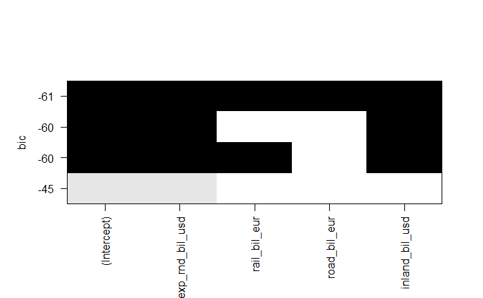

```r
plot(regsubsets_exhaustive, scale = "bic")
```

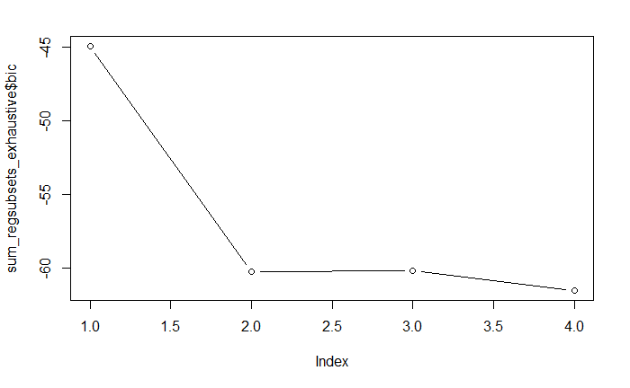

```r
plot(sum_regsubsets_exhaustive$bic, type = "b")
```

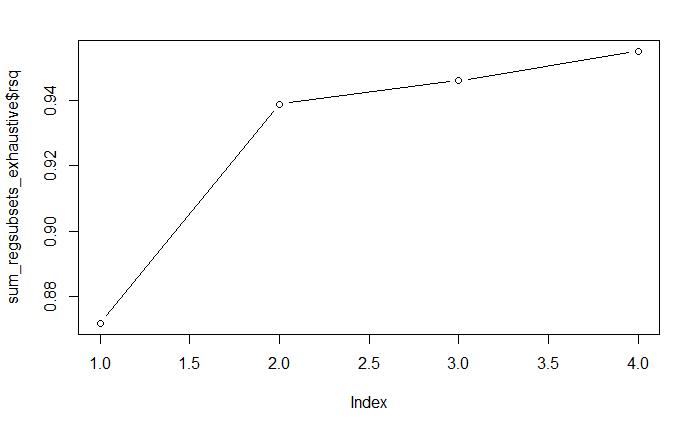

```r
plot(sum_regsubsets_exhaustive$rsq, type = "b")
```